# R-Tutorial & Collection of Useful Commands

```r
ppMS = ggplot(mtcars2, aes(x = mpg, y = hp, group = cyl)) + geom_point(aes(color = cyl))

# We can change the colors as above; e.g.
ppMS + scale_color_manual(values = vMyColors, labels = c("4 cyl.", "6 cyl.", "8 cyl."))


# Also, could of course distinguish points for different numbers of cylinders
# by markers rather than colors (or both).

# In this case, cyl really needs to be of type character, because, in contrast
# to colors, markers cannot vary continuously.



# ------------------------------------------------------------------------- #

# CONTINUOUS CASE

# ------------------------------------------------------------------------- #


# Plot hp against mpg, and distinguish points by color based on value of qsec:
ppMS = ggplot(mtcars, aes(x = mpg, y = hp, group = qsec)) + geom_point(aes(color = qsec))

# To specify colors, need to use scale_color_gradient rather than
# scale_color_manual:
ppMS + scale_color_gradient(low = "white", high = "blue")

# The analogous holds for the filling (if marker-shapes are specified that can
# be filled):
ppMS = ggplot(mtcars, aes(x = mpg, y = hp, group = qsec)) + geom_point(aes(color = qsec),
    shape = 21) + scale_color_gradient(low = "white", high = "blue") + scale_fill_gradient(low = "white",
    high = "blue")
```

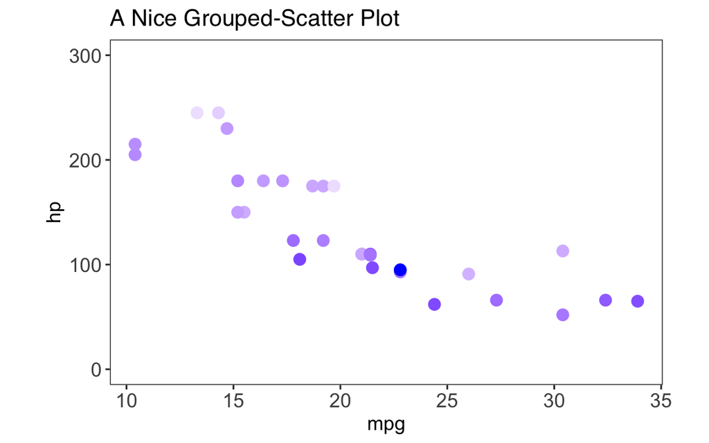

```r
# Nice, final grouped scatter-plot:

ggplot(mtcars, aes(x = mpg, y = hp, group = qsec)) + geom_point(aes(color = qsec,
    fill = qsec), size = 3, shape = 21) + scale_color_gradient(low = "white", high = "blue") +
    scale_fill_gradient(low = "white", high = "blue") + plotOptions + scale_y_continuous(limits = c(0,
    300), breaks = seq(0, 300, by = 100)) + theme(legend.position = "none") + labs(title = "A Nice Grouped-Scatter Plot")
```

Histogram:

```r
# ------------------------------------------------------------------------- #

# SINGLE HISTOGRAM

# ------------------------------------------------------------------------- #


# Based on single vector:

ggplot() + geom_histogram(aes(x = mNormDraws[, 2]))

# Based on column in dataframe:
ggplot(data = mData) + geom_histogram(aes(x = norm2))

# note that here we only need to specify the x-variable in aes()


# Change y-axis from frequency to density:

ggplot() + geom_histogram(aes(x = mNormDraws[, 2], y = ..density..))

ggplot(data = mData) + geom_histogram(aes(x = norm2, y = ..density..))


# Specify number of bins directly:
ggplot(data = mData) + geom_histogram(aes(x = norm2, y = ..density..), bins = 10)

# Specify number of bins with binwidth:
ggplot(data = mData) + geom_histogram(aes(x = norm2, y = ..density..), binwidth = 0.5)


# Change color and filling:
ggplot(data = mData) + geom_histogram(aes(x = norm2, y = ..density..), color = "black",
    fill = "grey", alpha = 0.2)


# Add line: (here: add actual pdf of N(5,1))
vThisNormPDF = dnorm(vx, 5, 1)
ggplot() + geom_histogram(aes(x = mNormDraws[, 2], y = ..density..)) + geom_line(aes(x = vx,
    y = vThisNormPDF))

# Could also do this with dataframe, but then we need same number of draws as
# 'elements' in the vector that represents the line (here: function
# evaluations)


# ------------------------------------------------------------------------- #

# MULTIPLE HISTOGRAMS IN SINGLE PLOT

# ------------------------------------------------------------------------- #

ggplot(data = mData) + geom_histogram(aes(x = norm2, y = ..density..), color = "blue",
    fill = "blue", alpha = 0.2) + geom_histogram(aes(x = norm3, y = ..density..),
    color = "red", fill = "red", alpha = 0.2)


# A separate histogram of one variable for each value of some third variable:
# e.g. a separate histogram of hp for each value of cyl, each with different
# color:

ggplot(mtcars2, aes(x = hp, fill = cyl)) + geom_histogram(aes(x = hp, y = ..density..,
    color = cyl), position = "identity")

# Should make bars a bit transparent:
ggplot(mtcars2, aes(x = hp, fill = cyl)) + geom_histogram(aes(x = hp, y = ..density..,
    color = cyl), position = "identity", alpha = 0.6)
```

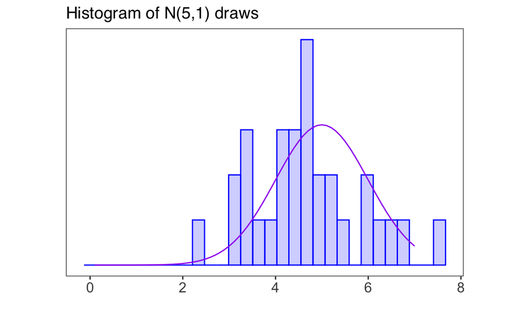

```r
# Taken together, nice histogram plots:

vThisNormPDF = dnorm(vx, 5, 1)

ggplot() + plotOptions + geom_histogram(aes(x = mNormDraws[, 2], y = ..density..),
    color = "blue", fill = "blue", alpha = 0.2) + geom_line(aes(x = vx, y = vThisNormPDF),
    color = "purple") + labs(x = "", y = "", title = "Histogram of N(5,1) draws") +
    theme(axis.ticks.y = element_blank(), axis.text.y = element_blank())
```

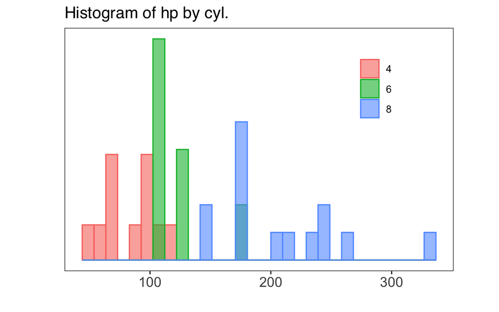

```r
ggplot(mtcars2, aes(x = hp, fill = cyl)) + plotOptions + geom_histogram(aes(x = hp,
    y = ..density.., color = cyl), position = "identity", alpha = 0.6) + theme(legend.title = element_blank(),
    legend.position = c(0.8, 0.75)) + labs(x = "", y = "", title = "Histogram of hp by cyl.") +
    theme(axis.ticks.y = element_blank(), axis.text.y = element_blank())
```

Bar-Plot:

```r
# Compute mean of Normal draws for each column of mNormDraws (dimension of
# multiv. Normal):

mDataBP = data.frame(norms = c(1, 2, 3), means = apply(mNormDraws, 2, mean))
```

```r
# Illustrate:

ggplot(data = mDataBP, aes(x = norms, y = means)) + geom_bar(stat = "identity")

# Adjust appearance of bars:
ggplot(data = mDataBP, aes(x = norms, y = means)) + geom_bar(stat = "identity", color = "blue",
    fill = "blue", alpha = 0.2)
```

```r
# To change x-axis, it is best to first make R realize that it is a discrete
# rather than continuous variable:
mDataBP$norms = as.character(mDataBP$norms)
```

```r
ggplot(data = mDataBP, aes(x = norms, y = means)) + geom_bar(stat = "identity", color = "blue",
    fill = "blue", alpha = 0.2) + scale_x_discrete(labels = c("1st", "2nd", "3rd"))
```

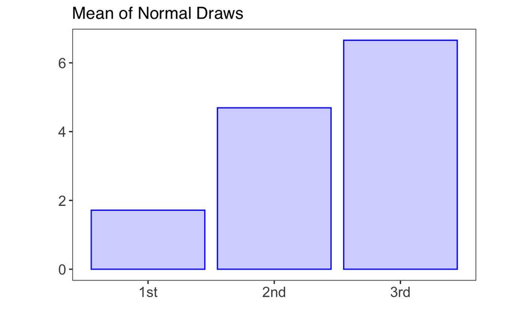

```r
# Taken together, nice bar-plot:

ggplot(data = mDataBP, aes(x = norms, y = means)) + plotOptions + geom_bar(stat = "identity",
    color = "blue", fill = "blue", alpha = 0.2) + scale_x_discrete(labels = c("1st",
    "2nd", "3rd")) + labs(x = "", y = "", title = "Mean of Normal Draws")
```

Combine several plots as panels in single figure:

```r
# Note: when producing a latex document with these plots, it is a better idea
# to produce the plots individually and assemble them in latex.  (more
# flexibility)

# Three plots for illustration:
plotOptionsCommonHere = list(plotOptions, ylim(c(0, 6)), scale_x_continuous(limits = c(-2,
    10), breaks = seq(-2, 10, by = 2)))
pp1 = ggplot(data = mData) + plotOptionsCommonHere + geom_histogram(aes(x = norm1),
    color = "blue", fill = "blue", alpha = 0.2) + labs(x = "", y = "", title = "norm1")

pp2 = ggplot(data = mData) + plotOptionsCommonHere + geom_histogram(aes(x = norm2),
    color = "blue", fill = "blue", alpha = 0.2) + labs(x = "", y = "", title = "norm2")

pp3 = ggplot(data = mData) + plotOptionsCommonHere + geom_histogram(aes(x = norm3),
    color = "blue", fill = "blue", alpha = 0.2) + labs(x = "", y = "", title = "norm3")


# It might be useful to create an empty plot: (e.g. when creating a 3x3 figure,
# but have 8 plots)

ggplot() + theme_void()



# ------------------------------------------------------------------------- #

# FIRST APPROACH

# ------------------------------------------------------------------------- #


library(gridExtra)
library(ggpubr)
# (need both packages)

# Create 1 x 2 plot:
grid.arrange(pp1, pp2, ncol = 2)

# To save:
ggsave("myplot1.pdf", arrangeGrob(pp1, pp2, ncol = 2))


# Add title:
title = text_grob("Draws from two Normals", size = 14, face = "bold", vjust = 5)
grid.arrange(pp1, pp2, ncol = 2, top = title)

# Can specify widths:
grid.arrange(pp1, pp2, ncol = 2, top = title, widths = c(2, 2))

# Can also specify ordering of plots (useful when many more than just 2 plots
# are added):
grid.arrange(pp1, pp2, ncol = 2, top = title, widths = c(2, 2), layout_matrix = rbind(c(1,
    2)))


# All of these options need to be specified also in 'arrangeGrob()' when saving
# the plot.

# Note: it would make sense to delete y-axis ticks on the right plot as they
# are common to both and already shown in the left plot.



# ------------------------------------------------------------------------- #

# SECOND APPROACH

# ------------------------------------------------------------------------- #


library(patchwork)

# Create 1 x 2 plot as above:
(pp1 | pp2)

# Here we have the advantage that we can save the resulting plot and call it
# later:
ppTotal = (pp1 | pp2)
ppTotal

# Add title:
ppTotal + plot_annotation(title = "Draws from two Normals")

# With this approach, we do not need a special command for saving the plots,
# but can use 'ggsave()'.  However, one needs to create a large plot, because
# with many plots, default size window is usually too small:
ggsave("myplot2.pdf", width = 40, height = 25, units = "cm")
# Note: changing the width and height will also change the spacing between
# figures.


# 2 x 3 plots:
(pp1 | pp1 | pp1)/(pp1 | pp1 | pp1)

# Can have even more flexible plot-arrangement:
layout = "
      AABB
      AABB
      EEEE
      EEEE
    "
pp1 + pp1 + pp1 + plot_layout(design = layout)
ggsave("myplot2.pdf", width = 40, height = 25, units = "cm")

# For plots with legends: If all plots have the same legend, you can collect
# all them into one single legend using the following commands:
ppTotal + plot_layout(guides = "collect") + theme(legend.position = "bottom")
```

There are many more things that ggplot2 can do. For example, to create a grid-plot, use “geom_raster()” or “geom_rect()”, to create an area-plot, use “geom_area()”. A google search usually shows quick how to use these commands.

# 13 Workspace Management

If you have a big project, it makes sense to break up your code into several R-scripts. From one script, you can call another using the following command:

```r
source("mySeparateScript.R")  # load/run external script
```

You can also store all objects (the whole current workspace) to an .RData-file, which you can load in other scripts:

```r
# Save all objects from the current workspace to an '.RData'-file:
save.image(file = "myWorkspace.RData")

# Load the workspace from the file:
load("myWorkspace.RData")
```

To keep the workspace tidy/lean even in a longer code, one can use lists to store a collection of objects in a single object; a list. If in each iteration of a loop a plot is created, we can save all these plots into one list using the following commands:

```r
lMyPlots = list()  # create empty list before loop

for (ii in 1:10) {

    # create plot for iteration ii, something like this comes out: (as a matter
    # of fact, typically, a plot is saved as a list (containing its
    # attributes); see below)
    plotHere = list(1, "a", "b")

    # save plot to 'lMyPlots':
    lMyPlots = append(lMyPlots, list(plotHere))

    # and assign a name to this plot:
    nameForThisPlot = paste("plot", ii, sep = "_")

    if (ii == 1) {
        # at the first iteration, lMyPlots is empty, so use this:
        names(lMyPlots) = c(names(lMyPlots), nameForThisPlot)
    } else {
        # later on, we can just use this:
        names(lMyPlots)[ii] = nameForThisPlot
    }

}
```

The same code can be used to store different regressions into a single list. See the section “Econometrics/Linear Regressions” for how to run regressions in a loop.

Saving a collection of different objects into a single list also enables us to delete a bunch of objects at once. This way, at the end of some longer section of code in our script, we can delete all objects that aren’t necessary for subsequent computations:

```r
a <- 4
b <- 3

# remove all objects but these two:
rm(list = ls()[!(ls() %in% c("lMyList", "lMyPlots"))])


# If you want to iteratively (e.g. after each section of your code) delete a
# bunch of objects, use this code:

a <- 4
b <- 3

# Define a vector containing the names of the objects you want to keep:
vToKeep = c("vToKeep", "lMyList", "a")
# Delete all objects but these:
rm(list = ls()[!(ls() %in% vToKeep)])

# At a later point, once you created some new objects ...:
b <- 3
c <- 5
# ... add the newly created objects that you want to keep to vToKeep ...:
vToKeep = c(vToKeep, "b")
# ... and delete all the rest:
rm(list = ls()[!(ls() %in% vToKeep)])

# (note that vToKeep contains the name of 'vToKeep' itself, otherwise this
# vector would be deleted too)
```

# 14 Further

## 14.1 Error Handling

Sometimes, it is inevitable that some code returns an error under some conditions, but we still want the code to continue running, i.e. we attempt at doing one thing, but if it doesn’t work, we try another thing. For such code-chunks,we can use “tryCatch”:

```r
# Try evaluating 'fLL()' (log-likelihood of some model) at vTheta, and return
# -99 if it doesn't work:
tryCatch(fLL(vTheta), error = function(e) {
    -99
})


# Try computing log-determinant of mA, and return NA if it doesn't work:
tryCatch(log(det(mA)), error = function(e) {
    NA
})
```

## 14.2 Timing

Sometimes, we want to record the time that R needs to execute a certain chunk of code:

```r
# Record the time at a given point: (typically before the code starts that you
# want to time)
timeStart = Sys.time()

# ... do operations ...

# Compute the time elapsed since ' timeStart' :
timeTotal = Sys.time() - timeStart


# To record the time needed to execute a single command/function: (here we
# record the time needed to draw 100 times from N(0,1))
system.time(rnorm(100))


# Let R 'sleep' for 4 seconds, i.e. do nothing:
Sys.sleep(4)
```

## 14.3 Linear Interpolation

We can use linear interpolation to impute missing values (NAs) in a vector:

```r
library(zoo)

vx = c(2, NA, 3, 2, 5)

na.approx(vx)  # imputes NA values in vx by linear interpolation
```

We can also use linear interpolation to evaluate a function at some intermediate value for its argument:

```r
vx = c(1, 2, 3)
vy = c(1, 4, 9)

# We can interpret this as a function y=f(x), for which we have 'observations'
# (1,1), (2,4), (3,9), and find f(2.5) by linear interpolation:
approx(vx, vy, xout = 2.5)
```

## 14.4 Optimization

For optimization of a function w.r.t. a scalar argument, it is easiest to use “optimize”:

```r
fFunToOpt = function(v) {
    (v - 3)^2
}
myOptimRes = optimize(fFunToOpt, interval = c(-5, 5))
myOptimRes$minimum  # minimizer ('argmin')
myOptimRes$objective  # function value at minimum ('min')
```

For optimization of a (scalar-valued) function w.r.t. a vector-valued argument, can use “optim”:

```r
fFunToOpt = function(v) {
    (v[1] - 3)^2 + v[2]^3
}

vTheta0 = c(0, 0)  # initial value
myOptimRes = optim(vTheta0, fFunToOpt, method = "BFGS")
myOptimRes$par  # minimizer ('argmin')
myOptimRes$value  # function value at minimum ('min')

# function can support several different methods, see ?optim
```

## 14.5 Complex Numbers

```r
# Define a complex number:
b = 3 + (0+2i)

Mod(b)  #modulus of b
Re(b)  #real part of b

# As you can see, 'i' is already defined by default in R.  That's why it's a
# good idea to avoid creating a variable 'i' yourself, as it would overwrite
# the variable 'i' that exists in R by default.  Same for 'pi'.
```

## 14.6 Further Useful Packages

In the course of this tutorial, we encountered many useful packages. Here are some more.

Package “imfr”: download data directly from IMF databases:

```r
library(imfr)

# see all datasets:
imf_ids(TRUE)

# Have a look at database 'IFS':
a = imf_codelist(database_id = "IFS")
# See what indicators are available in it:
a1 = imf_codes(codelist = "CL_INDICATOR_IFS")

# Download specified indicators from this database for specified countries, a
# specified year range, at specified frequency:
m_RGDP_Q_raw = imf_data(database_id = "IFS", indicator = c("NGDP_R_SA_XDC", "ENDA_XDC_USD_RATE"),
    country = c("AT", "AU"), start = "2021", end = "2022", freq = "Q", print_url = TRUE)
```

Package “countrycode”: translate between different official countrycodes:

```r
library(countrycode)

vsC_cc2 = c("AT", "AU")

# from iso2 to iso3:
countrycode(vsC_cc2, "iso2c", "iso3c")
```

```
## [1] "AUT" "AUS"
```

```r
# from iso2 to country names (in different languages):
countrycode(vsC_cc2, "iso2c", "country.name")
```

```
## [1] "Austria"   "Australia"
```

```r
countrycode(vsC_cc2, "iso2c", "country.name.de")
```

```
## [1] "Österreich" "Australien"
```

```r
countrycode(vsC_cc2, "iso2c", "country.name.fr")
```

```
## [1] "Autriche"  "Australie"
```

# 15 General Coding Advice

- Before you start coding, be clear on what you want to achieve and how to go about it (roughly).
- It is good practice to include at the top of your code:
  - a header with: your name, contact information (email/website), the purpose of the code (title and a short description)
  - an introductory code that i) deletes everything in the environment and console, ii) loads all packages used in script, and iii) defines all paths
- Clearly mark the different parts of your script, using comments, lines, spaces to create sections, subsections, etc.
- Adopt a naming convention, e.g.
  - use the so-called lowerCamelCase
  - start binary variables with “is” or “include” or other verb (e.g. isUtilityPositive or includeLimits)
  - start functions with f (e.g. fCombineStrings)
  - start object-names with v, a, m, i for vector, array, matrix, iterator, string (and combine, if necessary; e.g. vsVars is vector of strings
- Divide program into (many small) functions. This is easier to reuse, to test, and it (often) runs faster.
- For standard problems (e.g. interpolation, kernel density estimation, etc.), before you do it yourself, see whether there is a library that does it.
- For bigger projects, use Git to keep track of version changes.
- Think about optimization only once the code runs. And ask yourself whether an optimization (making code faster, graphs prettier, etc.) is really needed.